# AS07_final

R13342002張玳瑋

2025-05-11

```r
library(tidyverse)
library(readxl)
library(sf)
```

```r
library(ggplot2)
library(ggthemes)
library(RColorBrewer)
library(jsonlite)
```

## 載入資料

```r
# 出生資料
births <- read_excel("births_by_age_1.xlsx") %>%
  mutate(
    性別 = str_trim(性別),
    年份 = as.numeric(str_replace(年份, "年", "")) + 1911
  )

# 地圖資料
tw_map <- st_read("twCounty2010.geo.json", quiet = TRUE)
```

## 建立性別比例指標

```r
# 整理為 wide format
births_wide <- births %>%
  pivot_wider(names_from = 性別, values_from = 人數) %>%
  rename(男性 = `男`, 女性 = `女`) %>%
  mutate(
    性別比 = (女性 - 男性) / (女性 + 男性)
  )

# 取最新年度資料做地圖
latest_year <- max(births_wide$年份)
births_latest <- births_wide %>%
  filter(年份 == latest_year)
```

## 詮釋資料

```r
#name：人數
#資料範圍：102年-112年
#href：https://www.gender.ey.gov.tw/gecdb/Stat_Statistics_DetailData.aspx?sn=81ca3xOmq7PeQ19JLb29nw%40%40&d=m9ww9odNZAz2Rc5Ooj%24wIQ%40%40
#dep:內政部
#cat1：健康、醫療與照顧
#cat2：生育
#複分類：年度別，縣市別，性別，年齡別，發生登記別
```

## ❶ 地圖：112年新生兒性別比全台分佈

#### **✶ 新聞標題｜性別不平衡：台灣新生兒性別比地圖揭示長期偏差**

#### **✶ 所使用的綜合性指標｜性別差距指標 = (女 - 男) / (女 + 男)**

此指標顯示出某縣市新生兒性別的偏差程度，範圍會落在 -1 到 1 之間，越接近 0 表示越平衡，正值代表女性較多，負值代表男性較多。

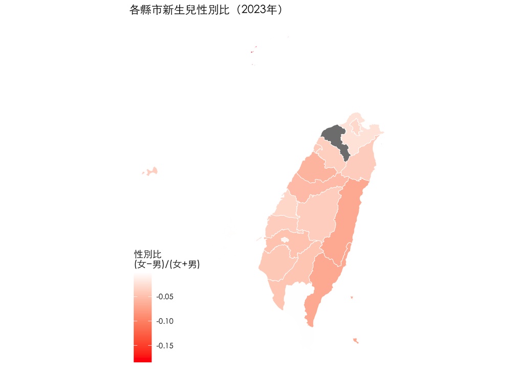

```r
# 縣市名稱一致化處理
births_latest$縣市別 <- str_replace_all(births_latest$縣市別, "台", "臺")
tw_map$COUNTYNAME <- str_replace_all(tw_map$COUNTYNAME, "台", "臺")

# 合併地圖與指標
map_data <- tw_map %>%
  left_join(births_latest, by = c("COUNTYNAME" = "縣市別"))

# 畫地圖
ggplot(map_data) +
  geom_sf(aes(fill = 性別比), color = "white") +
  scale_fill_gradient2(low = "red", mid = "white", high = "blue", midpoint = 0,
                       name = "性別比\n(女−男)/(女+男)") +
  labs(title = paste0("各縣市新生兒性別比（", latest_year, "年）")) +
  theme_map()+
  theme(
    text = element_text(family = "Heiti TC Light"),
    title = element_text(family = "Heiti TC Light")
  )
```

## ❷折線圖：臺北市 2013–2023 新生兒性別比

#### **✶ 新聞標題｜**臺北市10年來新生兒性別比持續失衡：男嬰長期占多，性別平等仍存隱性挑戰

**✶ 所使用的綜合性指標｜性別差距指標 = (女 - 男) / (女 + 男)**

此指標顯示出某縣市新生兒性別的偏差程度，範圍會落在 -1 到 1 之間，越接近 0 表示越平衡，正值代表女性較多，負值代表男性較多。

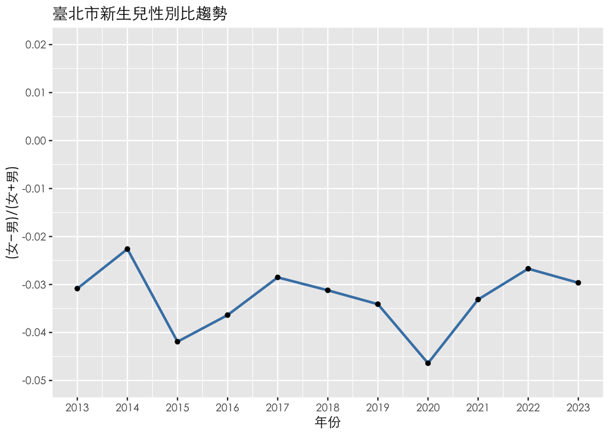

```r
# 指定縣市
trend_data <- births_wide %>%
  filter(縣市別 == "臺北市")

ggplot(trend_data, aes(x = 年份, y = 性別比)) +
  geom_line(color = "steelblue", size = 1) +
  geom_point() +
  scale_x_continuous(breaks = seq(min(trend_data$年份), max(trend_data$年份), by = 1)) +
  scale_y_continuous(
    breaks = c(0.02, 0.01, 0.00, -0.01, -0.02, -0.03, -0.04, -0.05),
    limits = c(-0.05, 0.02)
  ) +
  labs(title = "臺北市新生兒性別比趨勢",
       x = "年份", y = "(女−男)/(女+男)") +
    theme(
    text = element_text(family = "Heiti TC Light"),
    title = element_text(family = "Heiti TC Light")
  )
```

### 🗺 臺北市 2013–2023 新生兒性別比Finding

從圖中可見，臺北市2013年至2023年新生兒性別比（(女−男)/(女+男)）長期呈現負值，表示男嬰數量持續多於女嬰。儘管性別比波動範圍不大，但始終未突破零軸，最高約為-0.02，最低接近-0.05，顯示男嬰在出生人口中占比仍偏高。這樣的現象可能反映出潛在的社會文化因素，例如家庭對男嬰的偏好，或是自然性別比以外的結構性偏差。值得注意的是，雖然臺北市作為首都，教育程度與性別意識相對普及，性別比仍顯示出長期且穩定的偏差，說明即使在都市地區，性別平等的實踐仍面臨隱性挑戰，值得政策進一步關注。